# Causal Frontdoor Examples

Simon Brewer

5/21/2023

## Libraries and whatnot

```r
library(tidyverse)
# library(broom)
library(patchwork)
library(scales)
library(dagitty)
library(ggdag)
library(latex2exp)  # Easily convert LaTeX into arcane plotmath expressions
library(ggtext)     # Use markdown in ggplot labels

# Create a cleaner serifed theme to use throughout
theme_do_calc <- function() {
  theme_dag(base_family = "Times New Roman") +
    theme(plot.title = element_text(size = rel(1.5)),
          plot.subtitle = element_markdown())
}

# Make all geom_dag_text() layers use these settings automatically
update_geom_defaults(ggdag:::GeomDagText, list(family = "Times New Roman",
                                               fontface = "bold",
                                               color = "black"))
```

Examples taken from: https://arelbundock.com/posts/frontdoor/

## Front door path

The front door path is used to replace a back door path when there is an unknown (suspected) confounder ($u$). But this has the condition that there needs to be at least one mediating factors between the intervention and the outcome. So this won’t work:

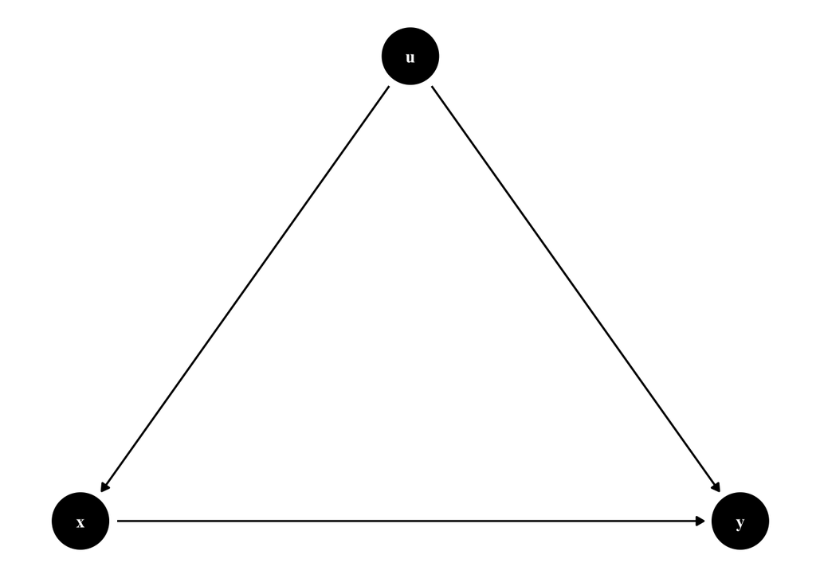

```r
fd_dag <- dagify(x ~ u,
                 y ~ x + u,
                 coords = list(x = c(x = 1, y = 3, u = 2),
                               y = c(x = 1, y = 1, u = 2)),
                 exposure = "x",
                 outcome = "y")

ggdag(fd_dag) +
  theme_dag()
```

But this will

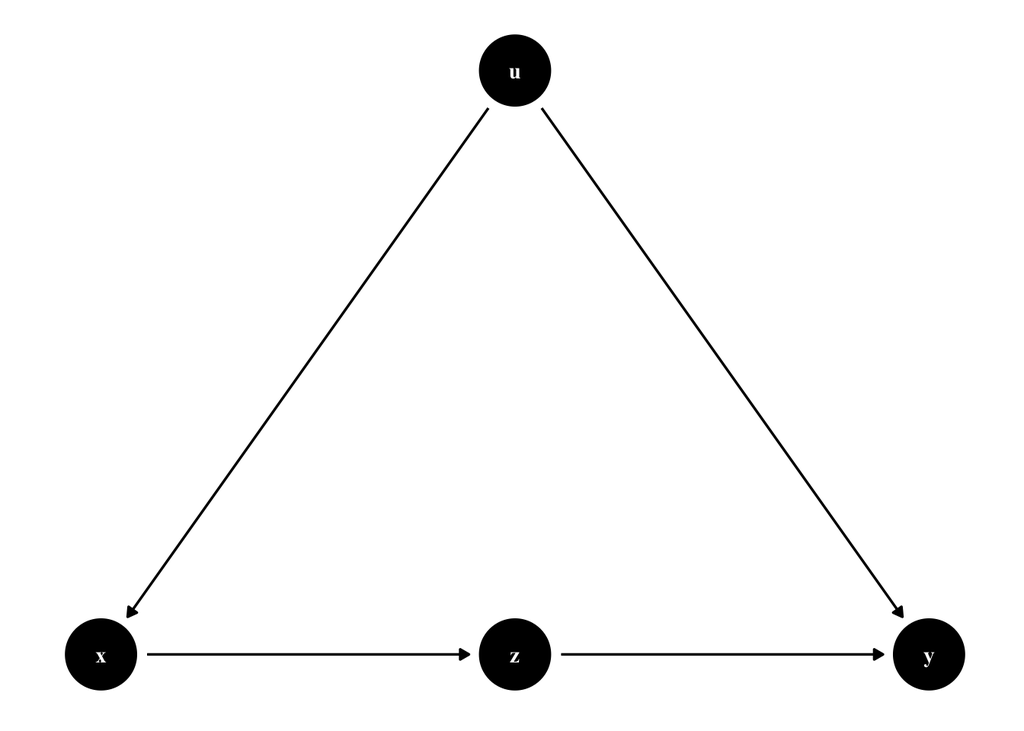

```r
fd_dag <- dagify(x ~ u,
                 z ~ x,
                 y ~ z + u,
                 coords = list(x = c(x = 1, y = 3, u = 2, z = 2),
                               y = c(x = 1, y = 1, u = 2, z = 1)),
                 exposure = "x",
                 outcome = "y")

ggdag(fd_dag) +
  theme_dag()
```

In this DAG:

- `x` is the intervention or covariate of causal interest
- `y` is the outcome
- `u` is an unknown confounder
- `z` is a mediating variable (mediates `y ~ x`)

Our goal is to estimate $P(Y|\mbox{do}(X))$. Unfortunately, this relationship between $X$ and $Y$ is confounded via a backdoor path with an unobserved variable $U$. The path is $X \leftarrow U \rightarrow Y$. Given the backdoor path, we can’t estimate the causal relationship (or we can but it will be biased).

We can instead, estimate the effect of $X$ on $Y$ indirectly through the front door path ($X \rightarrow Z \rightarrow Y$), by decomposing it into two links:

- The effect of $X$ and $Z$
- The effect of $Z$ on $Y$ given $X$

There are three steps here

- Estimate $P(Z|\mbox{do}(X))$
- Estimate $P(Y|\mbox{do}(Z), X)$
- Combine the two estimates

## Simulated data

All binary:

- `U`: $P=0.2$
- `X`: $P=0.1 + U \times 0.6$
- `Z`: $P=0.3 + X \times 0.5$
- `Y`: $P=0.1 + U \times 0.3 + Z \times 0.5$

```r
N = 1e5
U = rbinom(N, 1, prob = .2)
X = rbinom(N, 1, prob = .1 + U * .6)
Z = rbinom(N, 1, prob = .3 + X * .5)
Y = rbinom(N, 1, prob = .1 + U * .3 + Z * .5)
dat = data.frame(X, Z, Y)
```

The true effect of `X` on `Y` is $0.5 \times 0.5 = 0.25$. In this simple case, we should be able to obtain this effect by creating the two models (one for `Z`, one for `Y`) and multiplying the coefficients. First, start with a naive model (i.e. no accounting for any paths or mediators):

```r
fit <- lm(Y ~ X, dat)
summary(fit)
```

```
##
## Call:
## lm(formula = Y ~ X, data = dat)
##
## Residuals:
##     Min      1Q  Median      3Q     Max
## -0.6956 -0.2743 -0.2743  0.3044  0.7257
##
## Coefficients:
##             Estimate Std. Error t value Pr(>|t|)
## (Intercept) 0.274322   0.001610   170.4   <2e-16 ***
## X           0.421243   0.003426   123.0   <2e-16 ***
## ---
## Signif. codes:  0 '***' 0.001 '**' 0.01 '*' 0.05 '.' 0.1 ' ' 1
##
## Residual standard error: 0.4493 on 99998 degrees of freedom
## Multiple R-squared:  0.1314, Adjusted R-squared:  0.1313
## F-statistic: 1.512e+04 on 1 and 99998 DF,  p-value: < 2.2e-16
```

Which results in a biased estimate of 0.421. We can also try a model that assumes an independent effect of `X` and `Y`:

```r
fit <- lm(Y ~ X + Z, dat)
summary(fit)
```

```
##
## Call:
## lm(formula = Y ~ X + Z, data = dat)
##
## Residuals:
##     Min      1Q  Median      3Q     Max
## -0.7973 -0.1240 -0.1240  0.2028  0.8760
##
## Coefficients:
##             Estimate Std. Error t value Pr(>|t|)
## (Intercept) 0.124001   0.001624   76.34   <2e-16 ***
## X           0.173164   0.003272   52.92   <2e-16 ***
## Z           0.500086   0.002759  181.24   <2e-16 ***
## ---
## Signif. codes:  0 '***' 0.001 '**' 0.01 '*' 0.05 '.' 0.1 ' ' 1
##
## Residual standard error: 0.3898 on 99997 degrees of freedom
## Multiple R-squared:  0.3461, Adjusted R-squared:  0.3461
## F-statistic: 2.647e+04 on 2 and 99997 DF,  p-value: < 2.2e-16
```

And the effect is still biased (0.173).

### Front-door adjustment

First we estimate the effect of `X` on `Z`. Since there is no open backdoor, we do not need to control for other variables:

```r
step1 = lm(Z ~ X, dat)
```

Then, we estimate the effect of `Z` on `Y` while controlling for `X` to close the backdoor:

```r
step2 = lm(Y ~ Z + X, dat)
```

Finally, we combine the two estimates by multiplication:

```r
coef(step1)["X"] * coef(step2)["Z"]
```

```
##         X
## 0.2480798
```

## Frontdoor Algebra

We require the following assumptions (https://stats.stackexchange.com/questions/312992/causal-effect-by-back-door-and-front-door-adjustments):

- Full mediation: there is no directed path from `X` to `Y`, except through `Z`
- Unconfoundedness 1: There is no open backdoor from `X` to `Z`
- Unconfoundedness 2: All backdoors from `Z` to `Y` are blocked by `X`.

Step 1: Under assumption 2, the relationship between `X` and `Z` is not confounded. See DAG at the top - there’s no way to get from `X` to `Z` except the direct path. The other path is blocked by a collider at `Y`. As a result, we have:
$$P(Z|\mbox{do}(x)) = P(Z|X)$$

Step 2: In contrast, the relationship between `Z` and `Y` is confounded ($Z \leftarrow X \leftarrow U \rightarrow Y$. If we adjust for `X`, this blocks this path, and allows an unbiased estimate of the effect of `Z`. The backdoor formula is:

$$P(Y|\mbox{do}(Z)) = \sum_X P(Y|X,Z)P(X)$$

## **dosearch**

The **dosearch** package for R includes an algorithm that can automatically apply the rules of do-calculus to convert DAGs to adjustment formulas. Instead of manipulating equations ourselves like we did above, we can simply call the `dosearch` function to obtain the frontdoor adjustment formula automatically:

```r
library('dosearch')

data1 = "P(X, Y, Z)"

query1 = "P(Y | do(X))"

graph1 = "
U -> X
U -> Y
X -> Z
Z -> Y
"

# compute
frontdoor = dosearch(data1, query1, graph1)

# convert to Rmarkdown equation
cat(paste("$$", frontdoor$formula, "$$"))
```

```
## $$ \sum_{Z}\left(p(Z|X)\sum_{X}\left(p(X)p(Y|X,Z)\right)\right) $$
```

$$\sum_{Z}\left(p(Z|X)\sum_{X}\left(p(X)p(Y|X,Z)\right)\right)$$